# **Welcome!**

Hi! My name is **Ciaran Lowell**. Welcome to my personal Github Website, where I've compiled samples of my work.

I'm a 2021 Graduate of William and Mary, with a self-designed degree in Data Science and the Environment. I'm preparing to move to Reston, Virginia, and am looking for work in the DC and Northern Virginia Area.

I specialize in **Data Science and GIS**, with special interests in Environmental Science and Conservation. I have a strong background in **Python** and **ArcGIS**, along with many of Esri's other products such as StoryMaps and WebApps.

[You can read more about my work experience, skills, and hobbies in my resume!](https://docs.google.com/document/d/1QzZGDaOWF0MGqIVSSBquAIQLV7K6hiBmED7u6Pt2dvo/edit?usp=sharing)

I'm fascinated with storytelling using GIS, and using Python to analyze unconventional spatial data.

## **Examples of My GIS Work**

## **[Stacey Abrams vs. Voter Suppression](https://arcg.is/1eH9Wu)**

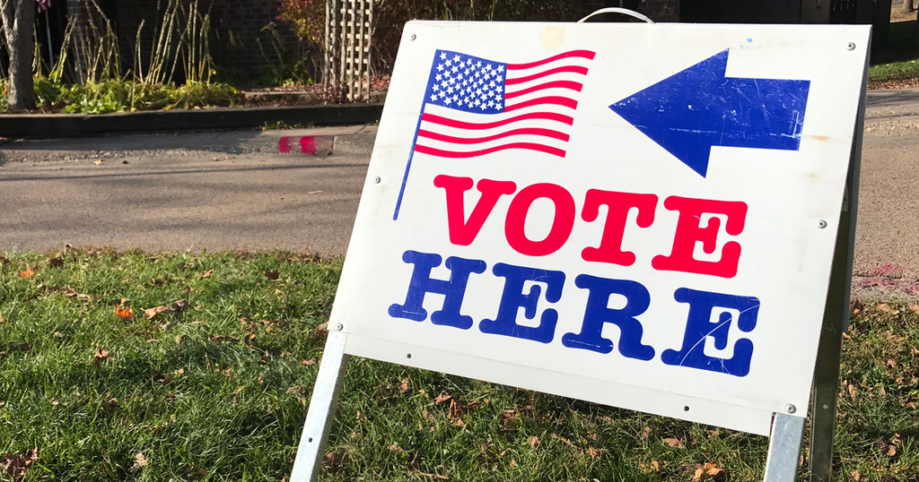

Hundreds of dedicated volunteers worked towards Georgia's shocking blue shift in the 2020 presidential election, but their battle wasn't finished yet.

An ESRI StoryMap I wrote describing the 2020 runoff Senate elections in Georgia, and integrating an ArcOnline WebApp I created showing polling locations in Fulton County, Georgia.

## **[Bringing Beavers Back to Scotland](https://arcg.is/1Dy0iq)**

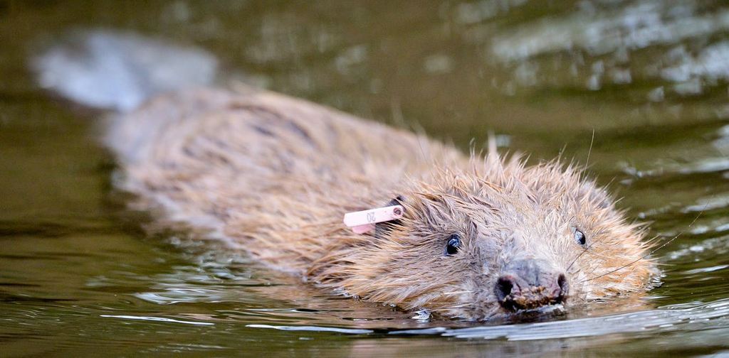

Scotland's conservationists have won a battle to re-establish the areas's native beaver population- but where should they start?

I created a habitat suitability model to find areas suitable for beaver re-introduction. This Cascade Storymap shows the results of my analysis, and provides a narrative about the beaver reintroduction efforts and the importance of their ecosystem role.

## **Examples of my Data Science Work**

## **[Training Neural Networks on Artificially-Generated Data](https://newfigton.github.io/2021/05/17/Project5/)**

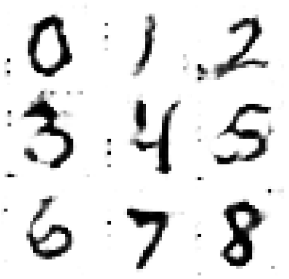

"Big Data" is a hot topic in today's world, but modern machine learning can carry signficant privacy concerns. Could we generate our own data to train models while still protecting privacy? In this project, I train a neural network to read handwritten numbers- without having ever seen human handwriting.

I use a GAN to generate artificial handwriting data, and then train a simple neural network on that data. Then, I test that network's performance on real handwriting data I compiled from my family.

## **[Demonstrating and Comparing Variable Selection Algorithms](https://newfigton.github.io/2021/05/08/Project2/)**

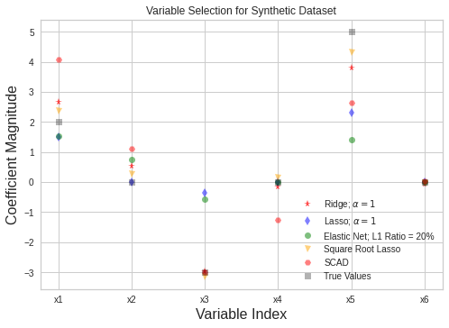

I demonstrate the performance of a variety of regressor models for variable selection on both real and synthetic (computer-generated) data.

## [Mapping Middle Earth- Least Cost Path](https://arcg.is/0GuDvX)

[figure not shown]

I worked as part of a team to determine Frodo and Sam's optimal route to take from the Shire to Mount Doom to destroy the One Ring.

To do this, we evaluated Middle Earth's dangerous aspects and created data layers simulating these dangers. Finally, we performed a least-cost path analysis and created this Cascade Storymap to show our workflow and results.

## **[Spatial Smash Brothers: Melee!](https://newfigton.github.io/SSBMHeatmaps/)**

[figure not shown]

Released in 2001, Super Smash Brothers: Melee still enjoys a fierce competitive scene two decades later. In 2020, a William and Mary Graduate won an unprecedented upset against a perennial titan of the game.

I wrote Python code to analyze lloD's stunning win against Hungrybox, and created several visualizations demonstrating where lloD won against Hungrybox, and what moves he won with.

[figure not shown]